# Data_Analyst_ND_Project1

#### 1. What is our independent variable? What is our dependent variable?

**Independent Variable** : List of words

**Dependent Variable** : Response time to recognise the color of the ink in list of words

#### 2. What is an appropriate set of hypotheses for this task? What kind of statistical test do you expect to perform? Justify your choices

**Null Hypothesis:** The population mean of the response times under congruent and incongruent condition are not different

**Alternate Hypothesis:** The population mean of the response times under congruent and incongruent condition are different

$$H_o : \mu_{congruent} = \mu_{incongruent}$$$$H_a : \mu_{congruent} \neq \mu_{incongruent} $$

I believe **dependent t-test for paired samples** is suitable in this scenario for the following reasons:

1. The same subject is used to record the time taken to recognise the color of the ink under two conditions (Congruent and incongruent).
2. The sample size in our experiment is less that thirty(n = 24). Hence, we prefer t-test for this experiment.
3. We assume the distribution of to be a gaussian distribution.
4. The statistics we use in this experiment for the subjects are mean of difference in samples, and sample standard deviation of the difference.
5. We get the t critical value from the t table with df = 23 and at an $$\alpha = 0.05$$ for a two tailed sample t test.
6. We assume the hypothetical mean difference of both the samples to be zero. $$ \mu_{congruent} - \mu_{incongruent} = 0 $$

#### 3. Report some descriptive statistics regarding this dataset. Include at least one measure of central tendency and at least one measure of variability.

Congruent data: (14.05,3.56)  
Incongruent data : (22.02,4.80)

Calculations are shown below.

```python
import pandas as pd

path = r'C:/Users/Pavan/Desktop/DAND Project 1/stroopdata.csv'

dataFrame = pd.read_csv(path)
dataFrame
```

|  | Subject | Congruent | Incongruent | Difference |
| --- | --- | --- | --- | --- |
| 0 | 1 | 12.079 | 19.278 | -7.199 |
| 1 | 2 | 16.791 | 18.741 | -1.950 |
| 2 | 3 | 9.564 | 21.214 | -11.650 |
| 3 | 4 | 8.630 | 15.687 | -7.057 |
| 4 | 5 | 14.669 | 22.803 | -8.134 |
| 5 | 6 | 12.238 | 20.878 | -8.640 |
| 6 | 7 | 14.692 | 24.572 | -9.880 |
| 7 | 8 | 8.987 | 17.394 | -8.407 |
| 8 | 9 | 9.401 | 20.762 | -11.361 |
| 9 | 10 | 14.480 | 26.282 | -11.802 |
| 10 | 11 | 22.328 | 24.524 | -2.196 |
| 11 | 12 | 15.298 | 18.644 | -3.346 |
| 12 | 13 | 15.073 | 17.510 | -2.437 |
| 13 | 14 | 16.929 | 20.330 | -3.401 |
| 14 | 15 | 18.200 | 35.255 | -17.055 |
| 15 | 16 | 12.130 | 22.158 | -10.028 |
| 16 | 17 | 18.495 | 25.139 | -6.644 |
| 17 | 18 | 10.639 | 20.429 | -9.790 |
| 18 | 19 | 11.344 | 17.425 | -6.081 |
| 19 | 20 | 12.369 | 34.288 | -21.919 |
| 20 | 21 | 12.944 | 23.894 | -10.950 |
| 21 | 22 | 14.233 | 17.960 | -3.727 |
| 22 | 23 | 19.710 | 22.058 | -2.348 |
| 23 | 24 | 16.004 | 21.157 | -5.153 |

```python
print "Mean of times recorded under congruent condition:"
dataFrame['Congruent'].mean()
```

```
Mean of times recorded under congruent condition:
```

```
14.051125000000004
```

```python
print "Mean of times recorded under incongruent condition:"
dataFrame['Incongruent'].mean()
```

```
Mean of times recorded under incongruent condition:
```

```
22.01591666666667
```

```python
print "Standard deviation of times recorded under congruent condition:"
dataFrame['Congruent'].std()
```

```
Standard deviation of times recorded under congruent condition:
```

```
3.559357957645195
```

```python
print "Standard deviation of times recorded under incongruent condition:"
dataFrame['Incongruent'].std()
```

```
Standard deviation of times recorded under incongruent condition:
```

```
4.797057122469138
```

#### 4. Provide one or two visualizations that show the distribution of the sample data. Write one or two sentences noting what you observe about the plot or plots.

For congruent data, the plot follows a right skewed normal distribution. For incongruent data, the spread is more compared to first plot. The maximum value reached to 35, which are extreme values/outliers.

When we look at the merged histograms, it clearly shows that response times recorded under incongruent condition is more than that of congruent condition. This is the observation we get from descriptive statistics, but to conclude this claim, we have to perform hypothesis testing.

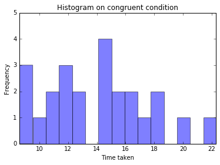

```python
%pylab inline
import matplotlib.pyplot as plt

congruent_results = dataFrame['Congruent']
plt.hist(congruent_results, bins =15, alpha = 0.5)
plt.title("Histogram on congruent condition")
plt.xlabel("Time taken")
plt.ylabel("Frequency")
plt.axis([8.6, 22.3, 0, 5])
plt.show()
```

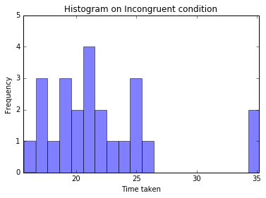

```python
incongruent_results = dataFrame['Incongruent']
plt.hist(incongruent_results, bins = 20, alpha = 0.5)
plt.title("Histogram on Incongruent condition")
plt.xlabel("Time taken")
plt.ylabel("Frequency")
plt.axis([15.6, 35.2, 0, 5])
plt.show()
```

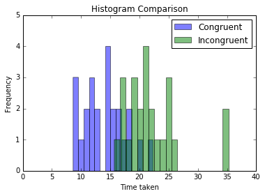

```python
congruent_results = dataFrame['Congruent']
incongruent_results = dataFrame['Incongruent']
plt.hist(congruent_results, bins =15, alpha = 0.5, label = 'Congruent')
plt.hist(incongruent_results, bins = 20, alpha = 0.5, label = 'Incongruent')
plt.title("Histogram Comparison")
plt.xlabel("Time taken")
plt.ylabel("Frequency")
plt.axis([0, 40, 0, 5])
plt.legend(loc = 'upper right')
plt.show()
```

#### 5. Now, perform the statistical test and report your results. What is your confidence level and your critical statistic value? Do you reject the null hypothesis or fail to reject it? Come to a conclusion in terms of the experiment task. Did the results match up with your expectations?

Results:

$$ \alpha = 0.05 $$$$ t_{critical} = \pm2.069 $$

Sample statistics:
n = 24
df = 23
Congruent Sample: (14.05,3.56)
Incongruent sample: (22.02, 4.80)
Difference in sample means statistics: (-7.96,4.86)
Hypothetical mean difference = 0
$$ \mu_{congruent} - \mu_{incongruent} = 0 $$ $$ t_{statistic} = (\bar{x}_{congruent} - \bar{x}_{incongruent}) - (\mu_{congruent} - \mu_{incongruent}) / (s_d/(\surd{n}) $$

t(23) = -8.02, p<.0001, two tailed

The difference in the means is considered to be extremely significant.

Based on the t statistic, we **reject the null hypothesis**, and conclude that the population mean of the response times under congruent and incongruent condition are different.

#### 6. Optional: What do you think is responsible for the effects observed? Can you think of an alternative or similar task that would result in a similar effect? Some research about the problem will be helpful for thinking about these two questions!

There are two theories that may explain the Stroop effect:

1. Speed of Processing Theory: the interference occurs because words are read faster than colors are named.
2. Selective Attention Theory: the interference occurs because naming colors requires more attention than reading words.

Similar task that would result in similar effect: Turn the words upside down or rotate them 90 degrees.